# Ladyball - the Story of a Hashtag

Anthony Munnelly

[@anspailpin](https://twitter.com/anspailpin)

https://ie.linkedin.com/in/anthonymunnelly

### Ladyball - Where It Begins

On January 13th of this year of grace, 2016, at about lunchtime, the surfing classes of Erin got a shock. This shock:

[figure not shown]

Nobody knew what to make of it, except that nobody seemed much to like it. Nobody knew what this Ladyball was for. People were almost certain that it was a joke, but for a joke it didn't seem all that funny.

1. Was the campaign a success?
2. Can a search of the `#ladyball` hashtag on Twitter answer this question?

### Tweet Metadata

The [Twitter api](https://dev.twitter.com/rest/reference/get/statuses/user_timeline) shows a sample tweet, broken down as a json object. Tweets are famous for being short and (sometimes) sweet. But the amount of information that's packed into one tweet is staggering, and a little bit frightening.

This is what it looks like:

```
{
    "coordinates": null,
    "favorited": false,
    "truncated": false,
    "created_at": "Wed Aug 29 17:12:58 +0000 2012",
    "id_str": "240859602684612608",
    "entities": {
      "urls": [
        {
          "expanded_url": "https://dev.twitter.com/blog/twitter-certified-products",
          "url": "https://t.co/MjJ8xAnT",
          "indices": [
            52,
            73
          ],
          "display_url": "dev.twitter.com/blog/twitter-c\u2026"
        }
      ],
      "hashtags": [

      ],
      "user_mentions": [

      ]
    },
    "in_reply_to_user_id_str": null,
    "contributors": null,
    "text": "Introducing the Twitter Certified Products Program: https://t.co/MjJ8xAnT",
    "retweet_count": 121,
    "in_reply_to_status_id_str": null,
    "id": 240859602684612608,
    "geo": null,
    "retweeted": false,
    "possibly_sensitive": false,
    "in_reply_to_user_id": null,
    "place": null,
    "user": {
      "profile_sidebar_fill_color": "DDEEF6",
      "profile_sidebar_border_color": "C0DEED",
      "profile_background_tile": false,
      "name": "Twitter API",
      "profile_image_url": "http://a0.twimg.com/profile_images/2284174872/7df3h38zabcvjylnyfe3_normal.png",
      "created_at": "Wed May 23 06:01:13 +0000 2007",
      "location": "San Francisco, CA",
      "follow_request_sent": false,
      "profile_link_color": "0084B4",
      "is_translator": false,
      "id_str": "6253282",
      "entities": {
        "url": {
          "urls": [
            {
              "expanded_url": null,
              "url": "http://dev.twitter.com",
              "indices": [
                0,
                22
              ]
            }
          ]
        },
        "description": {
          "urls": [

          ]
        }
      },
      "default_profile": true,
      "contributors_enabled": true,
      "favourites_count": 24,
      "url": "http://dev.twitter.com",
      "profile_image_url_https": "https://si0.twimg.com/profile_images/2284174872/7df3h38zabcvjylnyfe3_normal.png",
      "utc_offset": -28800,
      "id": 6253282,
      "profile_use_background_image": true,
      "listed_count": 10775,
      "profile_text_color": "333333",
      "lang": "en",
      "followers_count": 1212864,
      "protected": false,
      "notifications": null,
      "profile_background_image_url_https": "https://si0.twimg.com/images/themes/theme1/bg.png",
      "profile_background_color": "C0DEED",
      "verified": true,
      "geo_enabled": true,
      "time_zone": "Pacific Time (US & Canada)",
      "description": "The Real Twitter API. I tweet about API changes, service issues and happily answer questions about Twitter and our API. Don't get an answer? It's on my website.",
      "default_profile_image": false,
      "profile_background_image_url": "http://a0.twimg.com/images/themes/theme1/bg.png",
      "statuses_count": 3333,
      "friends_count": 31,
      "following": null,
      "show_all_inline_media": false,
      "screen_name": "twitterapi"
    },
    "in_reply_to_screen_name": null,
    "source": "<a href="//sites.google.com/site/yorufukurou/\"" rel="\"nofollow\"">YoruFukurou</a>",
    "in_reply_to_status_id": null
  },
  {
    "coordinates": null,
    "favorited": false,
    "truncated": false,
    "created_at": "Sat Aug 25 17:26:51 +0000 2012",
    "id_str": "239413543487819778",
    "entities": {
      "urls": [
        {
          "expanded_url": "https://dev.twitter.com/issues/485",
          "url": "https://t.co/p5bOzH0k",
          "indices": [
            97,
            118
          ],
          "display_url": "dev.twitter.com/issues/485"
        }
      ],
      "hashtags": [

      ],
      "user_mentions": [

      ]
    },
    "in_reply_to_user_id_str": null,
    "contributors": null,
    "text": "We are working to resolve issues with application management & logging in to the dev portal: https://t.co/p5bOzH0k ^TS",
    "retweet_count": 105,
    "in_reply_to_status_id_str": null,
    "id": 239413543487819778,
    "geo": null,
    "retweeted": false,
    "possibly_sensitive": false,
    "in_reply_to_user_id": null,
    "place": null,
    "user": {
      "profile_sidebar_fill_color": "DDEEF6",
      "profile_sidebar_border_color": "C0DEED",
      "profile_background_tile": false,
      "name": "Twitter API",
      "profile_image_url": "http://a0.twimg.com/profile_images/2284174872/7df3h38zabcvjylnyfe3_normal.png",
      "created_at": "Wed May 23 06:01:13 +0000 2007",
      "location": "San Francisco, CA",
      "follow_request_sent": false,
      "profile_link_color": "0084B4",
      "is_translator": false,
      "id_str": "6253282",
      "entities": {
        "url": {
          "urls": [
            {
              "expanded_url": null,
              "url": "http://dev.twitter.com",
              "indices": [
                0,
                22
              ]
            }
          ]
        },
        "description": {
          "urls": [

          ]
        }
      },
      "default_profile": true,
      "contributors_enabled": true,
      "favourites_count": 24,
      "url": "http://dev.twitter.com",
      "profile_image_url_https": "https://si0.twimg.com/profile_images/2284174872/7df3h38zabcvjylnyfe3_normal.png",
      "utc_offset": -28800,
      "id": 6253282,
      "profile_use_background_image": true,
      "listed_count": 10775,
      "profile_text_color": "333333",
      "lang": "en",
      "followers_count": 1212864,
      "protected": false,
      "notifications": null,
      "profile_background_image_url_https": "https://si0.twimg.com/images/themes/theme1/bg.png",
      "profile_background_color": "C0DEED",
      "verified": true,
      "geo_enabled": true,
      "time_zone": "Pacific Time (US & Canada)",
      "description": "The Real Twitter API. I tweet about API changes, service issues and happily answer questions about Twitter and our API. Don't get an answer? It's on my website.",
      "default_profile_image": false,
      "profile_background_image_url": "http://a0.twimg.com/images/themes/theme1/bg.png",
      "statuses_count": 3333,
      "friends_count": 31,
      "following": null,
      "show_all_inline_media": false,
      "screen_name": "twitterapi"
    },
    "in_reply_to_screen_name": null,
    "source": "<a href="//sites.google.com/site/yorufukurou/\"" rel="\"nofollow\"">YoruFukurou</a>",
    "in_reply_to_status_id": null
  }
```

### Tweepy

*Tweepy* is now the standard module for interacting with Twitter in Python. Each Tweepy search returns an iterable Tweepy result set object. Each iteration is a Tweepy object, that compares to the `.json` we saw just now like so:

| .json | Tweepy |
| --- | --- |
| `result[0]['created_at']` | result[0].created_at |
| `result[0]['user']['screen_name']` | result[0].user.screen_name |

### Collecting the Tweets

In the current case, tweets were collected by running a program that had two functions. The first function created the api that allowed us to interact with Twitter in the first place, and the second then collected and pickled the tweets.

### Creating the api

You have to register an app with Twitter in order to use the api. Once created, your app supplies you with four passwords - consumer_key, consumer_secret, access_token, and access_token_secret. It is, of course, extremely bad practice to write these into any program, so I prefer to store them as .json and load them at the start. This is the straight-forward code to do so. In previous iterations of tweepy, it was necessary to set a rate-limit-checker yourself - this is now part of the package. Progress is a wonderful thing.

```
def create_the_api(my_login):

    # Log in to Twitter
    with open(my_login, 'r') as f:
        keys = json.load(f)

    auth = tweepy.OAuthHandler(keys['consumer_key'],
                               keys['consumer_secret'])
    auth.set_access_token(keys['access_token'],
                          keys['access_token_secret'])

    return tweepy.API(auth, wait_on_rate_limit=True,
                      wait_on_rate_limit_notify=True)

api = create_the_api(MY_URL)
```

### Twitter Rate Limits

[Twitter limits api access](https://dev.twitter.com/rest/public/rate-limiting). Depending on what you're looking for, you can get fifteen or 180 requests every fifteen minutes. No more. So once we hit that limit, we have no option but to wait out the fifteen minutes until we're ready to go again.

Tweepy has an `api.rate_limit_status()` method that shows where we stand for different requests. This is one I made earlier:

[output not shown]

[output not shown]

### Creating the tweet-finder function

Having created the api function, this is the function that finds the tweets, with a helper function that I'm about to explain.

```
def max_id_finder(temp):
    # A helper function to stop us collecting
    # the same data over and over again
    #(tweepy.Result) -> (int)

    ids = [int(tweet.id) for tweet in temp]
    ids.sort()

    return ids[0]


def hashtag_searcher(hashtag, count=180, api=api):
    if hashtag[0] == '#': # Allow for whether or not the
                          # user has included # as part of
                          # her hashtag
        hashtag = '%23' + hashtag[1:]
    else:
        hashtag = '%23' + hashtag

    tweets = []
    temp = []
    for i in range(count):
        print i
        if temp != []: # Checks to see if loop has run already,
                       # and thus needs the max_id parameter
            temp = api.search(hashtag,
                              max_id = max_id_finder(temp))
        else:
            temp = api.search(hashtag)

        [tweets.append(t) for t in temp]

    timestamp = datetime.datetime.today()
     # Get rid of the %23 to create a valid filename
    filename = hashtag[3:] + timestamp.strftime('%Y%m%d')

    with open(filename, 'w') as f:
        pickle.dump(tweets, f)

    return tweets
```

So this `hashtag_searcher()` function creates two lists, tweets and temp. When the api.search method is called, the results are returned to temp up to the api_rate_limit. Each of the results are then appended to the main, tweets, list, and the once the 15 minute interval has clicked away, the search renews. However, instead of starting over again, it starts at the max_id of the last returned value - it goes back to where it left off, in other words.

Once the full count has run, the tweets list is both is pickled and returned - a belt and braces undertaking, in keeping with the long time these searches can take.

```
if __name__ == '__main__':
    api = create_the_api("my_twitter_login.json")
    tweets = hashtag_searcher('ladyball', 1000, api)
```

### Analysing the Tweets

With the tweets successfully harvested and pickled, we can analyse them using this super iPython notebook.

```python
import tweepy
import pandas as pd
import matplotlib.pyplot as plt
import pickle
import glob
```

I've pickled these `#ladyball` tweets since January 14th. So, what I'm going to do next is

1. Load up the pickles from where they're stored into a single list, `tweets_prime`.
2. Prune that list to remove the duplicates. Every tweet has its own unique id, identified as `id` or `id_str`. We'll use that to catch the spares.

```python
ladyballs = glob.glob("~/pickled_ladyballs/*")
```

```python
tweets_prime = []
for ball in ladyballs:
    with open(ball) as f:
        temp = pickle.load(f)
        [tweets_prime.append(t) for t in temp]
```

```python
print type(tweets_prime[0])
len(tweets_prime)
```

```
<class 'tweepy.models.Status'>
```

```
9686
```

```python
id_watcher = []
ladyballs = []
for t in tweets_prime:
    if t.id_str not in id_watcher:
        ladyballs.append(t)
        id_watcher.append(t.id_str)

print len(ladyballs)
```

```
3774
```

### Looking at the Tweet Dates

The easiest way to look at the tweet dates is to create a data frame and use that to pull from the `ladyballs` list such data as a data frame is unsuited to storing, such as text. My method of choice for creating dataframes is to create a dictionary and then turn that dictionary into a dataframe. And for creating dictionary, there's nothing as handy as the defaultdict in the collections module. It's so neat and tidy.

```python
from collections import defaultdict

def create_dataframe(tweetList):
    '''
    (list) -> (data frame)
    '''
    my_initial_dict = defaultdict(list)

    my_initial_dict['created_at'] = [t.created_at for t in tweetList]
    my_initial_dict['screen_name'] = [t.user.screen_name for t in tweetList]
    my_initial_dict['id_str'] = [t.id_str for t in tweetList]
    my_initial_dict['followers_count'] = [t.user.followers_count for t in tweetList]
    my_initial_dict['text'] = [t.text for t in tweetList]
    my_initial_dict['description'] = [t.user.description for t in tweetList]
    my_initial_dict['retweet_count'] = [t.retweet_count for t in tweetList]

    new_dataframe = pd.DataFrame(my_initial_dict, columns = ['created_at',
                                                            'screen_name',
                                                            'id_str',
                                                            'followers_count',
                                                            'text'
                                                           'description',
                                                           'retweet_count'])
    return new_dataframe

df_ladyballs = create_dataframe(ladyballs)
# Life is much handier if we sort the list by date.
df_ladyballs.sort_values('created_at', inplace=True, ascending=True)
print df_ladyballs.head(10)
```

```
              created_at      screen_name              id_str  \
1725 2016-01-09 06:58:06     HatTrickClub  685717163265527808
1724 2016-01-11 15:28:17     deboralkelly  686570333000855552
1723 2016-01-13 12:44:10  theladyball_com  687253805474250752
1722 2016-01-13 13:30:17  theladyball_com  687265410987601921
1721 2016-01-13 13:46:08       kevjclarke  687269401922502656
1720 2016-01-13 13:53:59     JulietteGash  687271373731938304
1719 2016-01-13 13:58:48  theladyball_com  687272586410115073
1718 2016-01-13 14:13:00        EamonLowe  687276162083590144
1717 2016-01-13 14:34:49     garethgregan  687281653551599616
1716 2016-01-13 14:35:45  theladyball_com  687281888059371521

      followers_count textdescription  retweet_count
1725               48             NaN              0
1724             5312             NaN              1
1723              374             NaN              1
1722              374             NaN              7
1721              497             NaN              0
1720             6298             NaN              1
1719              374             NaN              0
1718             1982             NaN              0
1717             1024             NaN              1
1716              374             NaN              0
```

### Looking at the Tweet text

We'll look at the first twenty tweets to see what we can figure out as regards the *fons et origio* of the `#ladyball` hashtag.

```python
first_ten_tweets = list(df_ladyballs['id_str'].head(20).values)
for item in first_ten_tweets:
    for t in ladyballs:
        if item == t.id_str:
            print t.user.screen_name + " (" + str(t.user.followers_count) + " followers)"
            print t.text
            print "-"*50
```

```
HatTrickClub (48 followers)
@footscc @MagpiesCMCC @vicpremcricket last ball #ladyball!
--------------------------------------------------
deboralkelly (5312 followers)
Kudos to Ovarian Cancer Canada's #ladyball campaign -- it's a bold move to save women's lives https://t.co/OvvClwpv5f #marketing
--------------------------------------------------
theladyball_com (374 followers)
Trust us girls, you need #Ladyball in your life...Coming soon x #WatchThisSpace https://t.co/6QjOuJudLl
--------------------------------------------------
theladyball_com (374 followers)
Is she a keeper? She is if she has a #Ladyball. https://t.co/Ipa3YLdfA1
--------------------------------------------------
kevjclarke (497 followers)
Assumed this was legit until I saw Ger Brennan as spokesperson. #ladyball https://t.co/UOQAd3UcvU
--------------------------------------------------
JulietteGash (6298 followers)
Surely a piss take? #Ladyball @Louise_Johnston
--------------------------------------------------
theladyball_com (374 followers)
@Louise_Johnston Yaaaay Louise! Delighted to hear you're on board #Ladyball is here to stay #squadgoals 💃🏼👠⚽️
--------------------------------------------------
EamonLowe (1982 followers)
Thanks @JulietteGash

Twitter, what are you waiting for?

Introducing The #Ladyball! https://t.co/650CCgkXr6 https://t.co/7XZdyGZGDF
--------------------------------------------------
garethgregan (1024 followers)
This is hilarious! (at least I hope it's a joke).. #ladyball https://t.co/8WLLzbvoCi
--------------------------------------------------
theladyball_com (374 followers)
@ShinnFinn @denisefmckenna a revolution in evolution #Ladyball is made 4 ladies by ladies to encourage women to get involved in team sports😊
--------------------------------------------------
theladyball_com (374 followers)
@JonjoQ @ShinnFinn @denisefmckenna @Louise_Johnston glad you think so! Btw not just for GAA, all sports needing a ball welcome #Ladyball
--------------------------------------------------
theladyball_com (374 followers)
@ponyyelof @ShinnFinn @denisefmckenna @Louise_Johnston not at all, here it is! #Ladyball https://t.co/YfZoth6jtf
--------------------------------------------------
```

[output cut: 9 more lines]

```
theladyball_com (374 followers)
@sweetpmac introducing #Ladyball! Launching now with our ambassador Dub football Ger Brennan https://t.co/cWhKAAneRY
--------------------------------------------------
theladyball_com (374 followers)
@Anderson8Paul @PaulFedayn nothing fake about this! Launch pics just done 😄 #Ladyball https://t.co/lmctdxZw2l
--------------------------------------------------
StFanahan (735 followers)
Remember people, if you're going shifting make sure to check for @theladyball_com #ladyball
--------------------------------------------------
ElaineBucko (3445 followers)
Really thought @theladyball_com was some sort of bizarre joke but NO,it appears to be real. WHAT THE WHAT. #Ladyball https://t.co/2fw1mpxrnz
--------------------------------------------------
ElaineBucko (3445 followers)
"Women just had to make do with balls meant for men." All those years, slumming it with O'Neill's official match balls. NO MORE.  #Ladyball
--------------------------------------------------
```

### Looking at the Life Cycle

We can look at the life cycle of the `ladyball` hashtag to see when people were talking about it, and we can do this by grouping by date - kind of. To group by date, we have to

1. Create a new column on the dataframe, with a string representation of the date
2. Group by this column. This is how that works out in this case:

```python
day_month = [tweet.strftime('%d %b') for tweet in df_ladyballs['created_at']]
df_ladyballs['day'] = day_month
ladyballs_by_day = df_ladyballs.groupby('day')
for a, b in ladyballs_by_day:
    print a, b.created_at.count()
```

```
09 Jan 1
11 Jan 1
13 Jan 901
14 Jan 966
15 Jan 1208
16 Jan 381
17 Jan 75
18 Jan 68
19 Jan 90
20 Jan 26
21 Jan 36
22 Jan 18
23 Jan 3
```

### Looking at the Exposure

It's not true to say that a tweet is only seen by someone's followers. A tweet can be quoted or retweeted, it can found in a search, it can be found when a hashtag is trending. All these things. But as there's no point in throwing up our hands and saying ah, who knows?, the convention has become to look at a tweet's reach, or exposure, as being dependent on that particular tweeter's followers. So, what is the follower distribution like among the `#ladyball` tweeters?

```
{'boxes': [<matplotlib.lines.Line2D at 0x115b721d0>],
 'caps': [<matplotlib.lines.Line2D at 0x11b408410>,
 'fliers': [<matplotlib.lines.Line2D at 0x11b663e50>],
 'means': [],
 'medians': [<matplotlib.lines.Line2D at 0x116a80790>],
 'whiskers': [<matplotlib.lines.Line2D at 0x12d25e0d0>,
```

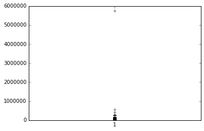

```python
%matplotlib inline
plt.boxplot(df_ladyballs.followers_count)
```

That's one crazy-looking boxplot. Let's see the actual figures.

```python
print df_ladyballs.followers_count.describe()
```

```
count       3774.000000
mean        5543.403286
std        95562.944061
min            0.000000
25%          236.000000
50%          578.500000
75%         1486.250000
max      5738471.000000
Name: followers_count, dtype: float64
```

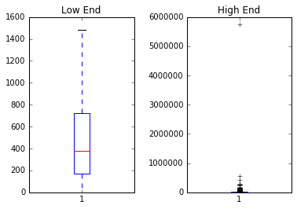

```python
%matplotlib inline
high_end = df_ladyballs[df_ladyballs['followers_count'] > 1486]
low_end = df_ladyballs[df_ladyballs['followers_count'] < 1486]
fig, ax = plt.subplots(1,2)
ax[0].boxplot(low_end.followers_count.values)
ax[0].set_title('Low End')
ax[1].boxplot(high_end.followers_count.values)
ax[1].set_title('High End')
fig.subplots_adjust(wspace = 0.5)
```

#### Plotting Aside

We shuld note that we're plotting `high_end.followers_count.values` rather than `high_end.followers_count`. This is because we've taken a slice of the original `df_ladyballs` data frame, this throws off the indexing, and the thrown indexing goes on to throw `matplotlib`. There may be a more elegant way around this problem than calling `values`, but calling `values` works and that's enough for me.

### Dealing with the Outliers

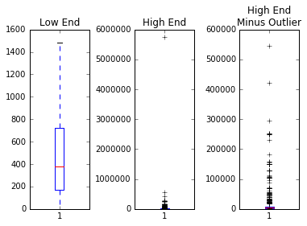

```python
high_end_minus_outlier = high_end[high_end['followers_count'] < 5738471]

%matplotlib inline
fig, ax = plt.subplots(1,3)
ax[0].boxplot(low_end.followers_count.values)
ax[0].set_title('Low End')
ax[1].boxplot(high_end.followers_count.values)
ax[1].set_title('High End')
ax[2].boxplot(high_end_minus_outlier.followers_count.values)
ax[2].set_title('High End\nMinus Outlier')
fig.subplots_adjust(wspace = 0.75)
```

And again we're looking at distribution that skews very strongly to the right. We still can't even make out the box in the boxplot, such the outlier dominance in the dataset. Let's look at the top tweets by `follower_count`.

```python
high_end_examined = high_end.sort_values('followers_count', ascending = False)
high_end_examined.head(25)
```

|  | created_at | screen_name | id_str | followers_count | textdescription | retweet_count | day |
| --- | --- | --- | --- | --- | --- | --- | --- |
| 3579 | 2016-01-19 21:39:25 | washingtonpost | 689562834330611712 | 5738471 | NaN | 30 | 19 Jan |
| 2855 | 2016-01-15 18:00:29 | Vibra1049 | 688058186528522240 | 545959 | NaN | 1 | 15 Jan |
| 1762 | 2016-01-16 22:29:05 | manuel_c | 688488168140713984 | 422373 | NaN | 0 | 16 Jan |
| 1171 | 2016-01-13 21:48:22 | SimonHoneydew | 687390760174489600 | 293945 | NaN | 21 | 13 Jan |
| 3003 | 2016-01-15 17:39:29 | spin1038 | 688052899390341120 | 252379 | NaN | 5 | 15 Jan |
| 2847 | 2016-01-15 18:01:09 | spin1038 | 688058353411616771 | 252379 | NaN | 1 | 15 Jan |
| 2388 | 2016-01-15 20:13:03 | spin1038 | 688091547414335490 | 252379 | NaN | 2 | 15 Jan |
| 1471 | 2016-01-13 18:41:23 | Independent_ie | 687343701123792897 | 250647 | NaN | 4 | 13 Jan |
| 543 | 2016-01-14 10:48:21 | Independent_ie | 687587048212029440 | 250646 | NaN | 2 | 14 Jan |
| 914 | 2016-01-13 23:16:42 | Independent_ie | 687412987989213184 | 250646 | NaN | 2 | 13 Jan |
| 1633 | 2016-01-13 16:53:20 | JOEdotie | 687316511925616640 | 231216 | NaN | 3 | 13 Jan |
| 3613 | 2016-01-19 12:48:24 | PaulOMahonyEire | 689429199220662273 | 183369 | NaN | 0 | 19 Jan |
| 3046 | 2016-01-15 17:27:00 | RTEgaa | 688049757823053825 | 156799 | NaN | 10 | 15 Jan |
| 2937 | 2016-01-15 17:49:19 | RTEgaa | 688055377003417600 | 156799 | NaN | 11 | 15 Jan |
| 3381 | 2016-01-14 22:15:26 | RossOCK | 687759956095971329 | 155383 | NaN | 6 | 14 Jan |
| 3696 | 2016-01-18 09:15:34 | TheDrum | 689013250718044160 | 150191 | NaN | 1 | 18 Jan |
| 3725 | 2016-01-17 17:15:11 | TheDrum | 688771560799338496 | 150191 | NaN | 2 | 17 Jan |
| 3525 | 2016-01-20 22:45:34 | TheDrum | 689941866108850177 | 150191 | NaN | 4 | 20 Jan |
| 1924 | 2016-01-16 12:20:22 | TheDrum | 688334979928080384 | 149758 | NaN | 1 | 16 Jan |
| 2221 | 2016-01-15 22:35:18 | TheDrum | 688127345329328128 | 149758 | NaN | 4 | 15 Jan |
| 3109 | 2016-01-15 14:52:50 | TheDrum | 688010961375096834 | 149758 | NaN | 5 | 15 Jan |
| 2589 | 2016-01-15 18:49:46 | TheDrum | 688070587886006272 | 149758 | NaN | 4 | 15 Jan |
| 2100 | 2016-01-16 01:02:01 | NewstalkFM | 688164266944274433 | 127998 | NaN | 0 | 16 Jan |
| 2872 | 2016-01-15 17:58:19 | NewstalkFM | 688057640019202048 | 127998 | NaN | 3 | 15 Jan |
| 2456 | 2016-01-15 19:37:22 | NewstalkFM | 688082566948220929 | 127998 | NaN | 3 | 15 Jan |

We need to go back to the original data to see the text descriptions of the accounts and the tweets in the top ten tweets here. We can use `id_str` to do that:

```python
my_ids = list(high_end_examined.id_str)[:10]
description_catcher = [] #So we don't print the descriptions more than once.
for tweet in ladyballs:
    if tweet.id_str in my_ids:
        print tweet.user.screen_name
        print "Followers: {:,}".format(tweet.user.followers_count)
        if tweet.user.description not in description_catcher:
            print tweet.user.description
            description_catcher.append(tweet.user.description)
        print tweet.created_at
        print tweet.text
        print '\n'
```

```
Independent_ie
Followers: 250,646
Official Twitter for Independent.ie, providing #breaking news content to 10million readers a month.
Get in touch: contact@independent.ie, #IndoSubmit
2016-01-14 10:48:21
RT @IndoSport: The 'Pink Ladyball' - innovative marketing at its finest: https://t.co/k4D2ED40Eo #LadyBall https://t.co/v2tZ60sDdK


Independent_ie
Followers: 250,646
2016-01-13 23:16:42
#Ladyball sparks strong reaction on Twitter.... https://t.co/Bow2tLfdcw


SimonHoneydew
Followers: 293,945
YouTuber, Cosplayer, Dancer, World #1 Anime Fan, Make-up Artist Tutor, League of Legends Pro Streamer, Podcaster, Co-Founder of Yogscast
2016-01-13 21:48:22
RT @theladyball_com: Don't break a nail, break boundaries with #Ladyball https://t.co/Ixpmn4Bky1


Independent_ie
Followers: 250,647
2016-01-13 18:41:23
RT @IndoSport: Pink 'Ladyball' for women sparks strong reaction on Twitter https://t.co/mBc1Gdn0Bb #Ladyball https://t.co/FrJyFi1x6d


manuel_c
Followers: 422,373
Luxury product consultant, social media strategist/addict. All about brand/customer experience. Food,travel & bourbon buff, red tape nemesis. Personal account.
2016-01-16 22:29:05
This Genius Marketing Campaign Says Everything About Women's Sports https://t.co/6itHoFsx3K #ladyball


spin1038
Followers: 252,379
No.1 for Music & Entertainment
2016-01-15 20:13:03
The real meaning behind the #Ladyball - https://t.co/MT43vnMAtB

```

[output cut: 10 more lines]

```
2016-01-15 18:00:29
¿Te sentirías más atraída por los deportes si los balones fueran rosados  #Ladyball? Aquí https://t.co/daGzpKmYVh https://t.co/qyEbtGbbpp


spin1038
Followers: 252,379
2016-01-15 17:39:29
The message behind the #Ladyball revealed - https://t.co/XAU59zFiXW https://t.co/oFdN7Jt7GW


washingtonpost
Followers: 5,738,471
Tweet-length breaking news, analysis from around the world. Founded in 1877. Follow our journalists on Twitter: https://t.co/VV0UBAMHg8
2016-01-19 21:39:25
What does the fake #ladyball campaign say about women’s sports? https://t.co/t4TLm97Lr6
```

### Chatter v Reach

Now we're coming to the heart of Twitter. The fundamental question you have to answer, as you're trying to get your message out on Twitter, is this: Does it matter who's talking about you? Are many tweets by tweeters with small amounts of followers as good as a single tweet by a user with a huge amount of followers?

### Time v Reach

This is our final graph of the evening. We're plotting the reach of the `#ladyball` hashtag against the number of times it was mentioned. We'll plot on different axes as it makes for a better visual comparison.

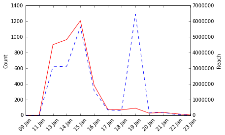

```python
tweet_count = []
tweet_reach = []
for a, b in ladyballs_by_day:
    tweet_count.append(b.created_at.count())
    tweet_reach.append(b.followers_count.sum())
%matplotlib inline
days = []
[days.append(a) for a, b in ladyballs_by_day]
%matplotlib inline
fig, ax1 = plt.subplots()
ax1.plot(tweet_count, "r-", label = 'count')
ax2 = ax1.twinx()
ax2.plot(tweet_reach, 'b--', label = 'reach')
ax1.set_xticks(range(len(days)))
ax1.set_xticklabels(days, rotation = 45)
ax1.set_ylabel('Count')
ax2.set_ylabel('Reach')
# http://matplotlib.org/examples/api/two_scales.html
```

### By Request: A Log Scale

There was a request during the presentation to view these charts as log scales, and I've now added that below. I would still argue the linear scales on different y-axes is the more visually impressive however.

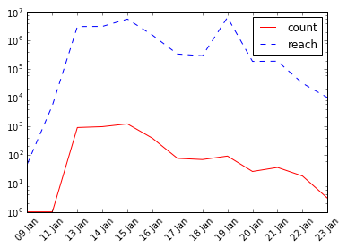

```python
tweet_count = []
tweet_reach = []
for a, b in ladyballs_by_day:
    tweet_count.append(b.created_at.count())
    tweet_reach.append(b.followers_count.sum())
%matplotlib inline
days = []
[days.append(a) for a, b in ladyballs_by_day]
%matplotlib inline
plt.semilogy(tweet_count, "r-", label = 'count')
plt.semilogy(tweet_reach, 'b--', label = 'reach')
plt.xticks(range(len(days)), days, rotation = 45)
plt.legend()
```

So here we can see that reach is reasonably proportional to chatter / number of tweets during the peak of the `#ladyball` hashtag's life cycle, but the hashtag reaches its highest reach just as it's dying off and people aren't interested anymore. These are the numbers:

```python
counter = len(tweet_count)
print "Date\tCount\tReach"
for c in range(counter):
    print "{}\t{:>5}\t{:>10,}".format(days[c], tweet_count[c], tweet_reach[c])
```

```
Date	Count	Reach
09 Jan	    1	        48
11 Jan	    1	     5,312
13 Jan	  901	 3,092,344
14 Jan	  966	 3,122,821
15 Jan	 1208	 5,644,684
16 Jan	  381	 1,554,422
17 Jan	   75	   338,193
18 Jan	   68	   293,447
19 Jan	   90	 6,451,310
20 Jan	   26	   186,680
21 Jan	   36	   189,709
22 Jan	   18	    31,835
23 Jan	    3	     9,999
```

### So. Was it Worth It?

Was the `#ladyball` tweet worth the controversy it caused?

#### Yes

It got people talking, which is the point of any publicity and/or advertising campaign.

#### Yes

The initial negative feedback was hugely overweighed by the positive mentions, especially the one in the [Washington Post](http://www.washingtonpost).

#### No

This is a little meta but: `#ladyball` was a success as a teaser to the campaign. But once the true point of `#ladyball` was revealed, what was left for people to be upset about, or happy about, or engaged with? There was no way to build from `#ladyball` on to the avowed purpose of it all, Lidl's sponsorship of ladies' football. The Washington Post piece was very worthy and is sure to be front-and-centre when the advertising agency put their bill together, but in what way did the `#ladyball`campaign get more people interested in ladies' Gaelic football or get more people shopping at Lidl? That case isn't proven.

### Addendum - the #serioussupport Hashtag

Brian Ward was good enough to point out in the post-presentation discussion on [Python Ireland](http://www.meetup.com/pythonireland/events/226191290/) that Lidl's post-ladyball hashtag is `#serioussupport`. So I ran the search detailed above for `#serioussupport` to see how that's been doing. We're not quite comparing like-with-like, but we'll certainly be able to get a sense of the comparison.

I've changed the code to create the dataframe to a function above, and I'll use that now to create a second dataframe to see what sort of business `#serioussupport` is doing.

```python
with open("serioussupport20160213") as f:
    support_list = pickle.load(f)

support = create_dataframe(support_list)
support.sort_values('created_at', inplace=True, ascending=True)
print support.head(10)
```

```
              created_at screen_name              id_str  followers_count  \
2027 2016-02-04 13:01:42    WeAreDub  695230749142880257             3758
1415 2016-02-04 13:01:42    WeAreDub  695230749142880257             3758
1414 2016-02-04 13:01:42    WeAreDub  695230749142880257             3758
1413 2016-02-04 13:01:42    WeAreDub  695230749142880257             3758
1412 2016-02-04 13:01:42    WeAreDub  695230749142880257             3758
1411 2016-02-04 13:01:42    WeAreDub  695230749142880257             3758
1410 2016-02-04 13:01:42    WeAreDub  695230749142880257             3758
1409 2016-02-04 13:01:42    WeAreDub  695230749142880257             3758
1408 2016-02-04 13:01:42    WeAreDub  695230749142880257             3758
1407 2016-02-04 13:01:42    WeAreDub  695230749142880257             3758

     textdescription  retweet_count
2027             NaN              1
1415             NaN              1
1414             NaN              1
1413             NaN              1
1412             NaN              1
1411             NaN              1
1410             NaN              1
1409             NaN              1
1408             NaN              1
1407             NaN              1
```

### Looking at the Life-Cycle

```python
day_month = [tweet.strftime('%d %b') for tweet in support['created_at']]
support['day'] = day_month
support_by_day = support.groupby('day')
for a, b in support_by_day:
    print a, b.created_at.count()
```

```
04 Feb 945
05 Feb 216
06 Feb 193
07 Feb 421
08 Feb 34
09 Feb 36
10 Feb 46
11 Feb 43
12 Feb 65
13 Feb 29
```

So we see very busy engagement on February 4th which falls away then for the rest of the week. We also saw from looking at the first ten rows of the data frame that these are all from the WeAreDub account, which identifies itself as the official media partners of Dublin Camogie. Camogie and Ladies' football are sisters, but they are not the same organisation. Let's look at reach.

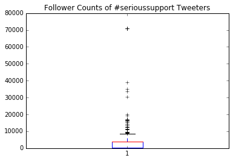

```python
plt.boxplot(support.followers_count.values)
plt.title('Follower Counts of #serioussupport Tweeters')
```

In an Irish context, that's not too bad. In comparision with the reach of `#ladyball`, it's not in the same league.

### The Tweeters Themselves

It's often interesting to see who's doing the actual tweeting. If it's the same few accounts over and over, the thing hasn't caught on. A diverse spread of tweeters is a sign of something having gone viral.

```python
support.screen_name.value_counts()
```

```
WeAreDub           934
LadiesFootball      40
meathladiesMLGF     39
CavanLGFA           34
Mayo_LGFA           24
LeinsterLGFA        20
MonaghanLadies      15
Twing_IRL           12
R0CSTR0NG           12
StCillesLadies      12
extratime_sport     11
erinoneill14        11
WHLadiesGAA          9
conorpbarry          8
itajrd               8
kerryladiesfoot      7
MidlandsSport        7
LMFMRADIO            7
allthingsmayo        7
LaoisLadies          6
cavangaascores       6
KeithOReillly        6
lidl_ireland         6
WaterfordLGFA        6
dublinh16            6
odea_jj              5
WexLadiesFoot        5
mc_claudine          5
AlanGunn2429         5
Armaghladiesga1      5
                  ...
thecailinrua         1
AineByrne94          1
Denis_Hurley         1
GhostxSkillz         1
LaurieRyan2          1
AilishBracken        1
marieva51            1
YoungBurkey          1
lynsavo              1
CarmelMcCartney      1
lauren_gray2015      1
eringannon1          1
VenomFilm            1
BreifneEarley        1
MichaelaMcfly        1
AmandaColeen         1
coilinduffy          1
AideenBorges123      1
Costello_Cc          1
ashjclery            1
KennedyLoulou        1
Roisinf1998          1
mancirishfest        1
FairGameCast         1
hannaoneillx         1
damienmulley         1
gormleyw             1
roisinm7             1
andreagilligan       1
Michelle_myers3      1
Name: screen_name, dtype: int64
```

And this is bad news indeed for the `#serioussupport` hashtag. There are 2,028 tweets in result set, and 934 of them are from one account. That's 46%. In terms of advertising success, `#ladyball` beats `#serioussupport` by a walkover.